# A study of wage inequality between men and women

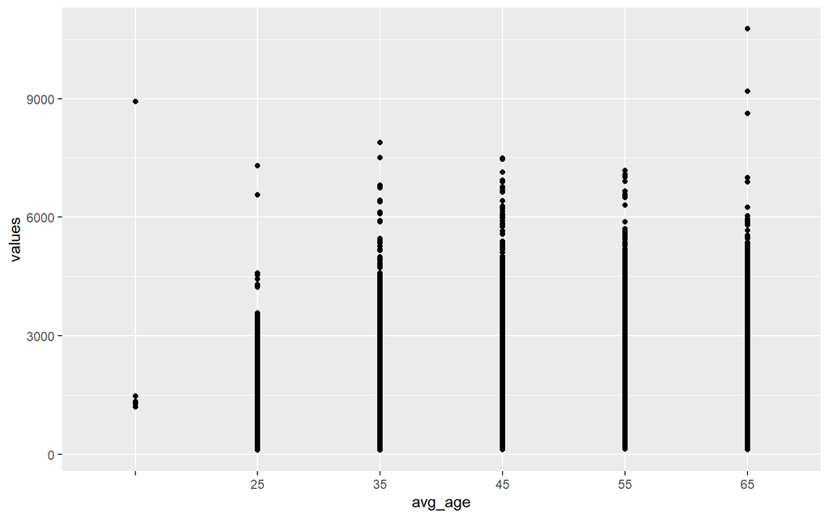

```r
ggplot(data_salary_age, aes(x = avg_age, y = values)) +
  geom_point() +
  geom_smooth(method='lm',formula=data_salary_age$values.plot~data_salary_age$avg_age.plot)
```

# linear regression between PPS and the percentage of income difference

is there a relation between PPS - purchasing power standard - and income difference? Does a wealthier country manage better the inequalities between men and women?

## importing the data

```r
d_list_PPS <- get_eurostat('sdg_10_10') #Salary by economic activity, age and sex
```

```
## Table sdg_10_10 cached at C:\Users\samyd\AppData\Local\Temp\RtmpwPIeu2/eurostat/sdg_10_10_date_code_TF.rds
```

## preprocessing the data

```r
data_PPS <- subset(d_list_PPS,  d_list_PPS$geo !="EU27" &  d_list_PPS$geo !="EU28" &  d_list_PPS$geo !="EA18"&  d_list_PPS$geo !="IE" & d_list_PPS$geo !="EA19"  & d_list_PPS$geo !="EL" & na_item == "VI_PPS_EU28_HAB" ,  select=c(geo,values))
result_PPS_avg_per_country <- aggregate(values~geo, data=data_PPS, FUN =mean)
result_PPS_and_inequality <- merge(result_PPS_avg_per_country,result_salary_difference_mean, by = "geo")
setnames(result_PPS_and_inequality, old=c("values.x","values.y"), new=c("PPS", "inequalty_percent"))
```

## plotting the linear regression

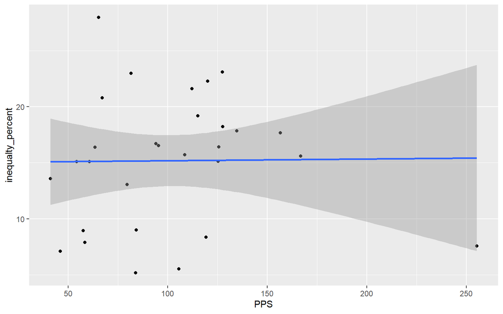

```r
ggplot(result_PPS_and_inequality, aes(x = PPS, y = inequalty_percent)) +
  geom_point() +
  geom_smooth(method='lm')
```

# conclusion

We can see that we have still progress to do in the domain of inequality of wage of men and women, but we’re still on the good way and things tends to accelerate with the raise of many feminist movements that provides new law propositions, new ideas and new ideologies to reduce those inequalities.

# for further

We could analyze the salary difference by sector to understand where are the principle difference of income. We can also count the number of men and women for each sector and relate this to the differences of wage and the correlation between age and income. Plotting the hour wage between men and women and see how the time worked influe on the salary. We could also use the k-nearest method to determine the salary to do it more fairly.

Samy DEMARCONNAY

08/01/2020